# Unit 3 Project

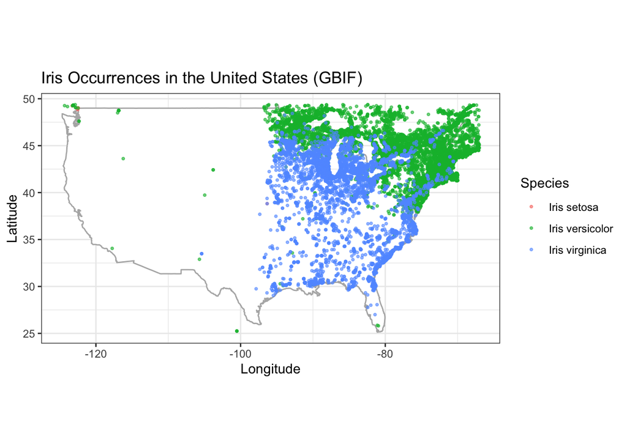

```r
# Q2
us.map <- map_data("usa")
us_lon_range <- range(us.map$long,na.rm=TRUE); us_lat_range <- range(us.map$lat,na.rm=TRUE)

iris_us <- iris_gps %>% filter(lon>=us_lon_range[1],lon<=us_lon_range[2],lat>=us_lat_range[1],lat<=us_lat_range[2])

ggplot(us.map,aes(long,lat,group=group))+
  geom_polygon(fill="white",colour="grey70")+
  geom_point(data=iris_us,aes(x=lon,y=lat,color=species),alpha=0.6,size=0.7,inherit.aes=FALSE)+
  coord_fixed(1.3)+
  labs(title="Iris Occurrences in the United States (GBIF)",x="Longitude",y="Latitude",color="Species")
```

# Q3

```
## ℹ Adding new coordinate system, which will replace the existing one.
```

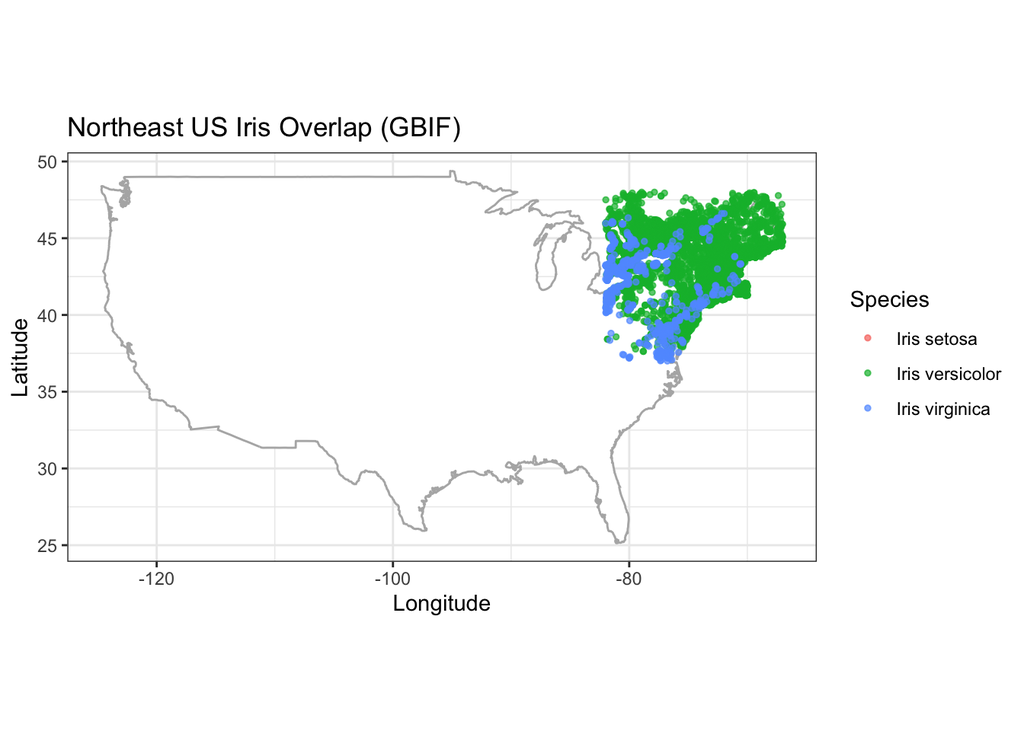

```r
ne_lon <- c(-82,-66); ne_lat <- c(37,48)
iris_ne <- iris_us %>% filter(lon>=ne_lon[1],lon<=ne_lon[2],lat>=ne_lat[1],lat<=ne_lat[2])

ggplot(us.map,aes(long,lat,group=group))+
  geom_polygon(fill="white",colour="grey70")+
  geom_point(data=iris_ne,aes(x=lon,y=lat,color=species),alpha=0.7,size=1.0,inherit.aes=FALSE)+
  coord_cartesian(xlim=ne_lon,ylim=ne_lat)+
  coord_fixed(1.3)+
  labs(title="Northeast US Iris Overlap (GBIF)",x="Longitude",y="Latitude",color="Species")
```

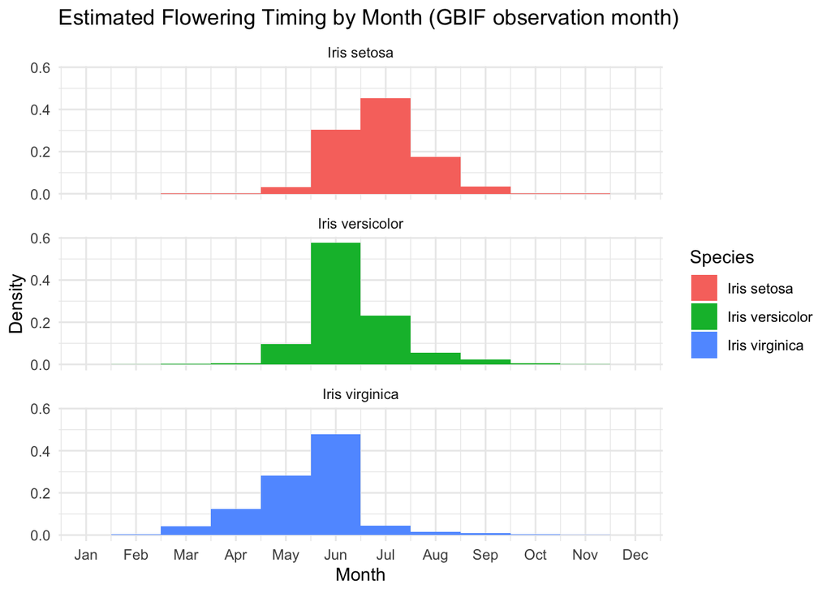

```r
# Q5
iris_months <- iris_gps %>% filter(!is.na(month),month>=1,month<=12)

ggplot(iris_months,aes(x=month,y=after_stat(density),fill=species))+
  geom_histogram(position="dodge",binwidth=1)+
  facet_wrap(~species,nrow=3)+
  scale_x_continuous(breaks=1:12,labels=month.abb,limits=c(1,12))+
  labs(title="Estimated Flowering Timing by Month (GBIF observation month)",x="Month",y="Density",fill="Species")+
  theme_minimal()
```

# Q4: What do you observe about the distribution of our three potential species in the US? # Answer: The GBIF map for the United States shows partial geographic separation among Iris setosa, # Iris versicolor, and Iris virginica, with noticeable areas of overlap, particularly in the northeastern # U.S. This indicates that geography alone does not completely isolate the species. Although they can # occur in the same regions, their coexistence does not imply they are the same species, since other # biological factors may limit gene flow. # What did this exercise tell you about our three potential species of iris? Describe the distribution of each. # Answer: This exercise demonstrates that the three iris species have distinct but overlapping ranges # within the United States. Iris setosa is primarily distributed in more northern regions. Iris versicolor # occurs mainly in the eastern and northeastern U.S. Iris virginica is found largely in the eastern and # southeastern U.S., with some overlap with Iris versicolor. The overlapping ranges show that geographic # location by itself is not sufficient to fully distinguish the species.